# Values and Data Types

A value is one of the fundamental things — like a word or a number — that a program manipulates. Some values are 5 (the result when we add 2 + 3), and "Hello, World!". These objects are classified into different classes, or data types: 4 is an integer, and “Hello, World!” is a string, so-called because it contains a string or sequence of letters. You (and the interpreter) can identify strings because they are enclosed in quotation marks.

We can specify values directly in the programs we write. For example we can specify a number as a literal just by (literally) typing it directly into the program (e.g., 5 or 4.32). In a program, we specify a word, or more generally a string of characters, by enclosing the characters inside quotation marks (e.g., "Hello, World!").

You can’t directly see the internal representations of values. You can, however, use the print function to see a printed representation in the output window.

```python
print(3.2)
```

```
3.2
```

```python
print("Hello, World!")
```

```
Hello, World!
```

# Operators and Operands

You can build complex expressions out of simpler ones using operators. Operators are special tokens that represent computations like addition, multiplication and division. The values the operator works on are called operands.

```python
20 + 32
```

```
52
```

```python
5 ** 2
```

```
25
```

```python
(5 + 9) * (15 - 7)
```

```
112
```

```python
print(7 + 5)
```

```
12
```

In Python 3, which we will be using, the division operator / produces a floating point result (even if the result is an integer; 4/2 is 2.0). If you want truncated division, which ignores the remainder, you can use the // operator (for example, 5//2 is 2).

```python
print(9 / 5)
print(5 / 9)
print(9 // 5)
```

```
1.8
0.5555555555555556
1
```

Pay particular attention to the examples above. Note that 9//5 truncates rather than rounding, so it produces the value 1 rather 2.

The truncated division operator, //, also works on floating point numbers. It truncates to the nearest integer, but still produces a floating point result. Thus 7.0 // 3.0 is 2.0.

```python
print(7.0 / 3.0)
print(7.0 // 3.0)
```

```
2.3333333333333335
2.0
```

The modulus operator, sometimes also called the remainder operator or integer remainder operator works on integers (and integer expressions) and yields the remainder when the first operand is divided by the second. In Python, the modulus operator is a percent sign (%). The syntax is the same as for other operators.

```python
print(7 // 3)    # This is the integer division operator
print(7 % 3)     # This is the remainder or modulus operator
```

```
2
1
```

**Exercise** What value is printed when the following statement executes?

print(18 / 4)

**Exercise** What value is printed when the following statement executes?

print(18.0 // 4)

Exercise What value is printed when the following statement executes?

print(18 % 4)

# Data Types and Variables

If you are not sure what class (data type) a value falls into, Python has a function called type which can tell you.

```python
print(type("Hello, World!"))
print(type(17))
print("Hello, World")
print(type(3.2))
```

```
<class 'str'>
<class 'int'>
Hello, World
<class 'float'>
```

What about values like "17" and "3.2"? They look like numbers, but they are in quotation marks like strings.

```python
print(type("17"))
print(type("3.2"))
```

```
<class 'str'>
<class 'str'>
```

They’re strings!

Strings in Python can be enclosed in either single quotes (') or double quotes ("), or three of each (''' or """)

```python
print(type('This is a string.'))
print(type("And so is this."))
print(type("""and this."""))
print(type('''and even this...'''))
```

```
<class 'str'>
<class 'str'>
<class 'str'>
<class 'str'>
```

Double quoted strings can contain single quotes inside them, as in "Bruce's beard", and single quoted strings can have double quotes inside them, as in 'The knights who say "Ni!"'. Strings enclosed with three occurrences of either quote symbol are called triple quoted strings. They can contain either single or double quotes:

```python
print('''"Oh no", she exclaimed, "Ben's bike is broken!"''')
```

```
"Oh no", she exclaimed, "Ben's bike is broken!"
```

Triple quoted strings can even span multiple lines:

```python
print("""This message will span
several lines
of the text.""")
```

```
This message will span
several lines
of the text.
```

a print statement can print any number of values as long as you separate them by commas. Notice that the values are separated by spaces when they are displayed.

```python
print(42, 17, 56, 34, 11, 4.35, 32)
print(3.4, "hello", 45)
```

```
42 17 56 34 11 4.35 32
3.4 hello 45
```

Remember not to put commas or spaces in your integers, no matter how big they are. Also revisit what we said in the previous chapter: formal languages are strict, the notation is concise, and even the smallest change might mean something quite different from what you intended.

**Exercise**:  
How can you determine the type of a variable?  
What is the data type of ‘this is what kind of data’?

One of the most powerful features of a programming language is the ability to manipulate variables. A variable is a name that refers to a value.

Assignment statements create new variables and also give them values to refer to.

```
message = "What's up, Doc?"
n = 17
pi = 3.14159
```

**Exercise:**  
What is printed when the following statements execute?

```
day = "Thursday"
day = 32.5
day = 19
print(day)
```

## Variable Names and Keywords

**Caution**

Variable names can never contain spaces.

Variable names can be arbitrarily long. They can contain both letters and digits, but they have to begin with a letter or an underscore. Although it is legal to use uppercase letters, by convention we don’t. If you do, remember that case matters. Bruce and bruce are different variables.

The underscore character ( _) can also appear in a name. It is often used in names with multiple words, such as my_name or price_of_tea_in_china. There are some situations in which names beginning with an underscore have special meaning, so a safe rule for beginners is to start all names with a letter.

If you give a variable an illegal name, you get a syntax error. In the example below, each of the variable names is illegal.

```
76trombones = "big parade"
more$ = 1000000
class = "Computer Science 101"
```

It turns out that class is one of the **Python keywords**. Keywords define the language’s syntax rules and structure, and they cannot be used as variable names. Python has thirty-something keywords (and every now and again improvements to Python introduce or eliminate one or two): and

as

assert

break

class

continue

def

del

elif

else

except

exec

finally

for

from

global

if

import

in

is

lambda

nonlocal

not

or

pass

raise

return

try

while

with

yield

True

False

None

**Exercise:**  
True or False: the following is a legal variable name in Python: A_good_grade_is_A+

# Type conversion functions

Sometimes it is necessary to convert values from one type to another. Python provides a few simple functions that will allow us to do that. The functions int, float and str will (attempt to) convert their arguments into types int, float and str respectively. We call these type conversion functions.

The int function can take a floating point number or a string, and turn it into an int. For floating point numbers, it discards the decimal portion of the number - a process we call truncation towards zero on the number line. Let us see this in action:

```python
print(3.14, int(3.14))
print(3.9999, int(3.9999))       # This doesn't round to the closest int!
print(3.0, int(3.0))
print(-3.999, int(-3.999))        # Note that the result is closer to zero

print("2345", int("2345"))        # parse a string to produce an int
print(17, int(17))                # int even works on integers
print(int("23bottles"))
```

```
3.14 3
3.9999 3
3.0 3
-3.999 -3
2345 2345
17 17
```

```
---------------------------------------------------------------------------
ValueError                                Traceback (most recent call last)
<ipython-input-16-f91031d268de> in <cell line: 8>()
      6 print("2345", int("2345"))        # parse a string to produce an int
      7 print(17, int(17))                # int even works on integers
----> 8 print(int("23bottles"))

ValueError: invalid literal for int() with base 10: '23bottles'
```

The last case shows that a string has to be a syntactically legal number, otherwise you’ll get one of those pesky runtime errors. Modify the example by deleting the bottles and rerun the program. You should see the integer 23.

The type converter float can turn an integer, a float, or a syntactically legal string into a float.

```python
print(float("123.45"))
print(type(float("123.45")))
```

```
123.45
<class 'float'>
```

The type converter str turns its argument into a string. Remember that when we print a string, the quotes are removed in the output window. However, if we print the type, we can see that it is definitely str.

```python
print(str(17))
print(str(123.45))
print(type(str(123.45)))
```

```
17
123.45
<class 'str'>
```

One common operation where you might need to do a type conversion is when you are concatenating several strings together but want to include a numeric value as part of the final string. Because we can’t concatenate a string with an integer or floating point number, we will often have to convert numbers to strings before concatenating them.

**Excercise:**  
What value is printed when the following statement executes?

print(int(53.785))

# Statements and Expressions

A statement is an instruction that the Python interpreter can execute. You have only seen the assignment statement so far. Some other kinds of statements that you’ll see in future chapters are while statements, for statements, if statements, and import statements. (There are other kinds too!)

An expression is a combination of literals, variable names, operators, and calls to functions. Expressions need to be evaluated. The result of evaluating an expression is a value or object.

If you ask Python to print an expression, the interpreter evaluates the expression and displays the result.

```python
print(1 + 1 + (2 * 3))
print(len("hello"))
```

```
8
5
```

```python
print(2 * len("hello") + len("goodbye"))
```

```
17
```

## Order of Operations

When more than one operator appears in an expression, the order of evaluation depends on the rules of precedence. Python follows the same precedence rules for its mathematical operators that mathematics does.

1. Parentheses have the highest precedence and can be used to force an expression to evaluate in the order you want. Since expressions in parentheses are evaluated first, `2 * (3-1)` is 4, and `(1+1)**(5-2)` is 8. You can also use parentheses to make an expression easier to read, as in (minute * 100) / 60: in this case, the parentheses don’t change the result, but they reinforce that the expression in parentheses will be evaluated first.
2. Exponentiation has the next highest precedence, so `2**1+1` is 3 and not 4, and `3*1**3` is 3 and not 27. Can you explain why?
3. Multiplication and both division operators have the same precedence, which is higher than addition and subtraction, which also have the same precedence. So `2*3-1` yields 5 rather than 4, and `5-2*2` is 1, not 6.
4. Operators with the same precedence are evaluated from left-to-right. In algebra we say they are left-associative. So in the expression 6-3+2, the subtraction happens first, yielding 3. We then add 2 to get the result 5. If the operations had been evaluated from right to left, the result would have been 6-(3+2), which is 1.

(Exception: Exponetial)

```python
print(2 ** 3 ** 2)     # the right-most ** operator gets done first!
print((2 ** 3) ** 2)   # use parentheses to force the order you want!
```

```
512
64
```

**Exercise:**  
What is the value of the following expression:

16 - 2 * 5 // 3 + 1

# Input

Our programs get more interesting if they don’t do exactly the same thing every time they run. One way to make them more interesting is to get input from the user. Luckily, in Python there is a built-in function to accomplish this task. It is called input.

`n = input("Please enter your name: ")`

```python
n = input("Please enter your name: ")
print("Hello", n)
```

```
Please enter your name: saif
Hello saif
```

Here is a program that turns a number of seconds into more human readable counts of hours, minutes, and seconds. A call to input() allows the user to enter the number of seconds. Then we convert that string to an integer. From there we use the division and modulus operators to compute the results.

```python
str_seconds = input("Please enter the number of seconds you wish to convert")
total_secs = int(str_seconds)

hours = total_secs // 3600
secs_still_remaining = total_secs % 3600
minutes =  secs_still_remaining // 60
secs_finally_remaining = secs_still_remaining  % 60

print("Hrs=", hours, "mins=", minutes, "secs=", secs_finally_remaining)
```

```
Please enter the number of seconds you wish to convert120
Hrs= 0 mins= 2 secs= 0
```

Exercise: What is printed when the following statements execute?

```
n = input("Please enter your age: ")
# user types in 18
print(type(n))
```

# Strings and Lists

## Working with the Characters of a String

The indexing operator (Python uses square brackets to enclose the index) selects a single character from a string. The characters are accessed by their position or index value. For example, in the string shown below, the 14 characters are indexed left to right from postion 0 to position 13.

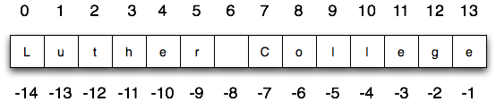

It is also the case that the positions are named from right to left using negative numbers where -1 is the rightmost index and so on. Note that the character at index 6 (or -8) is the blank character.

```python
school = "Luther College"
m = school[2]
print(m)

lastchar = school[-1]
print(lastchar)
```

```
t
e
```

The len function, when applied to a string, returns the number of characters in a string.

```python
fruit = "Banana"
print(len(fruit))
```

```
6
```

To get the last letter of a string, you might be tempted to try something like this:

```python
fruit = "Banana"
sz = len(fruit)
last = fruit[sz]       # ERROR!
print(last)
```

```
---------------------------------------------------------------------------
IndexError                                Traceback (most recent call last)
<ipython-input-26-e88e7bc79a01> in <cell line: 3>()
      1 fruit = "Banana"
      2 sz = len(fruit)
----> 3 last = fruit[sz]       # ERROR!
      4 print(last)

IndexError: string index out of range
```

That won’t work. It causes the runtime error IndexError: string index out of range. The reason is that there is no letter at index position 6 in "Banana". Since we started counting at zero, the six indexes are numbered 0 to 5. To get the last character, we have to subtract 1 from the length. Give it a try in the example above.

```python
fruit = "Banana"
sz = len(fruit)
lastch = fruit[sz-1]
print(lastch)
```

```
a
```

Typically, a Python programmer would combine lines 2 and 3 from the above example into a single line:

```
lastch = fruit[len(fruit)-1]
```

Though, from what you just learned about using negative indices, using fruit[-1] would be a more appropriate way to access the last index in a list.

You can still use the len function to access other predictable indices, like the middle character of a string.

```
fruit = "grape"
midchar = fruit[len(fruit)//2]
```

the value of midchar is "a"

**The Slice Operator**

A substring of a string is called a slice. Selecting a slice is similar to selecting a character:

```python
singers = "Peter, Paul, and Mary"
print(singers[0:5])
print(singers[7:11])
print(singers[17:21])
```

```
Peter
Paul
Mary
```

The slice operator [n:m] returns the part of the string starting with the character at index n and go up to but not including the character at index m. Or with normal counting from 1, this is the (n+1)st character up to and including the mth character.

If you omit the first index (before the colon), the slice starts at the beginning of the string. If you omit the second index, the slice goes to the end of the string.

```python
fruit = "banana"
print(fruit[:3])
print(fruit[3:])
```

```
ban
ana
```

**Concatenation and Repetition**

Again, as with strings, the + operator concatenates lists. Similarly, the * operator repeats the items in a list a given number of times.

```python
fruit1 = "apple"
fruit2 = "banana"
print(fruit1+fruit2)
print(fruit1*2)
```

```
applebanana
appleapple
```

**Count and Index**

As you create more complex programs, you will find that some tasks are commonly done. Python has some built-in functions and methods to help you with these tasks. This page will cover two helpful methods for both strings and lists: count and index.

The first method we’ll talk about is called count. It requires that you provide one argument, which is what you would like to count. The method then returns the number of times that the argument occured in the string/list the method was used on. There are some differences between count for strings and count for lists. When you use count on a string, the argument can only be a string. You can’t count how many times the integer 2 appears in a string, though you can count how many times the string “2” appears in a string. For lists, the argument is not restricted to just strings.

```python
a = "I have had an apple on my desk before!"
print(a.count("e"))
print(a.count("ha"))
```

```
5
2
```

The activecode window above demonstrates the use of count on a string. Just like with the turtle module when we had to specify which turtle was changing color or moving, we have to specify which string we are using count on.

```python
z = ['atoms', 4, 'neutron', 6, 'proton', 4, 'electron', 4, 'electron', 'atoms']
print(z.count("4"))
print(z.count(4))
print(z.count("a"))
print(z.count("electron"))
```

```
0
3
0
2
```

The other method that can be helpful for both strings and lists is the **index method**. The index method requires one argument, and, like the count method, it takes only strings when index is used on strings, and any type when it is used on lists. For both strings and lists, index returns the leftmost index where the argument is found. If it is unable to find the argument in the string or list, then an error will occur.

```python
music = "Pull out your music and dancing can begin"
bio = ["Metatarsal", "Metatarsal", "Fibula", [], "Tibia", "Tibia", 43, "Femur", "Occipital", "Metatarsal"]

print(music.index("m"))
print(music.index("your"))

print(bio.index("Metatarsal"))
print(bio.index([]))
print(bio.index(43))
```

```
14
9
0
3
6
```

All of the above examples work, but were you surprised by any of the return values? Remember that index will return the left most index of the argument. Even though “Metatarsal” occurs many times in bio, the method will only return the location of one of them.

Here’s another example.

```python
seasons = ["winter", "spring", "summer", "fall"]

print(seasons.index("autumn"))  #Error!
```

```
---------------------------------------------------------------------------
ValueError                                Traceback (most recent call last)
<ipython-input-34-81aaff4a97b6> in <cell line: 3>()
      1 seasons = ["winter", "spring", "summer", "fall"]
      2
----> 3 print(seasons.index("autumn"))  #Error!

ValueError: 'autumn' is not in list
```

In the activecode window above, we’re trying to see where “autumn” is in the list seasons. However, there is no string called autumn (though there is string called “fall” which is likely what the program is looking for). Remember that an error occurs if the argument is not in the string or list.

**Splitting Strings**

Two of the most useful methods on strings involve lists of strings. The split method breaks a string into a list of words. By default, any number of whitespace characters is considered a word boundary.

```python
song = "The rain in Spain..."
wds = song.split()
print(wds)
```

```
['The', 'rain', 'in', 'Spain...']
```

An optional argument called a delimiter can be used to specify which characters to use as word boundaries.

```python
song = "The rain in Spain..."
wds = song.split('ai')
print(wds)
```

```
['The r', 'n in Sp', 'n...']
```

Notice that the delimiter doesn’t appear in the result.

The inverse of the split method is **join**. You choose a desired separator string, (often called the glue) and join the list with the glue between each of the elements.

Strings are Immutable

One final thing that makes strings different from some other Python collection types is that you are not allowed to modify the individual characters in the collection. It is tempting to use the [] operator on the left side of an assignment, with the intention of changing a character in a string. For example, in the following code, we would like to change the first letter of greeting.

```python
greeting = "Hello, world!"
greeting[0] = 'J'            # ERROR!
print(greeting)
```

```
---------------------------------------------------------------------------
TypeError                                 Traceback (most recent call last)
<ipython-input-37-635c1b9842b9> in <cell line: 2>()
      1 greeting = "Hello, world!"
----> 2 greeting[0] = 'J'            # ERROR!
      3 print(greeting)

TypeError: 'str' object does not support item assignment
```

**Non-mutating Methods on Strings**

You should experiment with these methods so that you understand what they do. Note once again that the methods that return strings do not change the original.

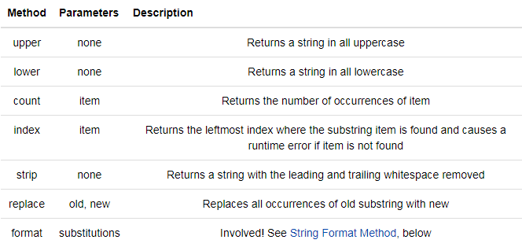

```python
ss = "    Hello, World    "

els = ss.count("l")
print(els)

print("***"+ss.strip()+"***")

news = ss.replace("o", "***")
print(news)
```

```
3
***Hello, World***
    Hell***, W***rld
```

```python
ss = "Hello, World"
print(ss.upper())

tt = ss.lower()
print(tt)
print(ss)
```

```
HELLO, WORLD
hello, world
Hello, World
```

**String Format Method**

Until now, we have created strings with variable content using the + operator to concatenate partial strings together. That works, but it’s very hard for people to read or debug a code line that includes variable names and strings and complex expressions.

```python
person = input('Your name: ')
greeting = 'Hello {}!'.format(person)
print(greeting)
```

```
Your name: saif
Hello saif!
```

There are several new ideas here!

The string for the format method has a special form, with braces embedded. Such a string is called a format string. Places where braces are embedded are replaced by the value of an expression taken from the parameter list for the format method. There are many variations on the syntax between the braces. In this case we use the syntax where the first (and only) location in the string with braces has a substitution made from the first (and only) parameter.

In the code above, this new string is assigned to the identifier greeting, and then the string is printed.

The identifier greeting was introduced to break the operations into a clearer sequence of steps. However, since the value of greeting is only referenced once, it can be eliminated with the more concise version:

```python
person = input('Enter your name: ')
print('Hello {}!'.format(person))
```

```python
origPrice = float(input('Enter the original price: $'))
discount = float(input('Enter discount percentage: '))
newPrice = (1 - discount/100)*origPrice
calculation = '${} discounted by {}% is ${}.'.format(origPrice, discount, newPrice)
print(calculation)
```

```
Enter the original price: $15
Enter discount percentage: 10
$15.0 discounted by 10.0% is $13.5.
```

```python
#For two decimal places, put :.2f inside the braces for the monetary values:
origPrice = float(input('Enter the original price: $'))
discount = float(input('Enter discount percentage: '))
newPrice = (1 - discount/100)*origPrice
calculation = '${:.2f} discounted by {}% is ${:.2f}.'.format(origPrice, discount, newPrice)
print(calculation)
```

**Exercise:**

What do you think fruit[:] means?

What will be stored in the variable ty below?

```
qu = "wow, welcome week!"
ty = qu.index("we")
```

What will be stored in the variable ty below?

```
qu = "wow, welcome week! Were you wanting to go?"
ty = qu.count("we")
```

What will be stored in the variable ht below?

```
rooms = ['bathroom', 'kitchen', 'living room', 'bedroom', 'closet', "foyer"]
ht = rooms.index("garden")
```

Create a variable output and assign to it a list whose elements are the words in the string str1.

```
str1 = "OH THE PLACES YOU'LL GO"
```

What is printed by the following statements:

```
s = "Ball"
s[0] = "C"
print(s)
```

What is printed by the following statements:

```
s = "python rocks"
print(s.count("o") + s.count("p"))
```

```
s = "python rocks"
print(s[1]*s.index("n"))
```

```
v = 2.34567
print('{:.1f} {:.2f} {:.7f}'.format(v, v, v))
```

## Lists

A list is a sequential collection of Python data values, where each value is identified by an index. The values that make up a list are called its elements. Lists are similar to strings, which are ordered collections of characters, except that the elements of a list can have any type and for any one list, the items can be of different types.

There are several ways to create a new list. The simplest is to enclose the elements in square brackets ( [ and ]).

```
[10, 20, 30, 40]
["spam", "bungee", "swallow"]
```

The first example is a list of four integers. The second is a list of three strings. As we said above, the elements of a list don’t have to be the same type. The following list contains a string, a float, an integer, and another list.

```
["hello", 2.0, 5, [10, 20]]
```

**Index Operator: Accessing Elements of a List or Tuple**

The syntax for accessing the elements of a list or tuple is the same as the syntax for accessing the characters of a string.

Try to predict what will be printed out by the following code, and then run it to check your prediction. (Actually, it’s a good idea to always do that with the code examples. You will learn much more if you force yourself to make a prediction before you see the output.)

```python
numbers = [17, 123, 87, 34, 66, 8398, 44]
print(numbers[2])
print(numbers[9-8])
print(numbers[-2])
```

```
87
123
8398
```

```python
prices = (1.99, 2.00, 5.50, 20.95, 100.98)
print(prices[0])
print(prices[-1])
print(prices[3-5])
```

```
1.99
100.98
20.95
```

**Length of List**

As with strings, the function len returns the length of a list (the number of items in the list). However, since lists can have items which are themselves sequences (e.g., strings), it important to note that len only returns the top-most length.

```python
alist =  ["hello", 2.0, 5]
print(len(alist))
print(len(alist[0]))
```

```
3
5
```

**List Slices**

he slice operation we saw with strings also work on lists. Remember that the first index is the starting point for the slice and the second number is one index past the end of the slice (up to but not including that element). Recall also that if you omit the first index (before the colon), the slice starts at the beginning of the sequence. If you omit the second index, the slice goes to the end of the sequence.

```python
a_list = ['a', 'b', 'c', 'd', 'e', 'f']
print(a_list[1:3])
print(a_list[:4])
print(a_list[3:])
print(a_list[:])
```

```
['b', 'c']
['a', 'b', 'c', 'd']
['d', 'e', 'f']
['a', 'b', 'c', 'd', 'e', 'f']
```

Concatenation and Repetition

Again, as with strings, the + operator concatenates lists. Similarly, the * operator repeats the items in a list a given number of times.

```python
fruit = ["apple","orange","banana","cherry"]
print([1,2] + [3,4])
print(fruit+[6,7,8,9])

print([0] * 4)
```

```
[1, 2, 3, 4]
['apple', 'orange', 'banana', 'cherry', 6, 7, 8, 9]
[0, 0, 0, 0]
```

**Splitting Strings**

The inverse of the split method is join. You choose a desired separator string, (often called the glue) and join the list with the glue between each of the elements.

```python
wds = ["red", "blue", "green"]
glue = ';'
s = glue.join(wds)
print(s)
print(wds)

print("***".join(wds))
print("".join(wds))
```

```
red;blue;green
['red', 'blue', 'green']
red***blue***green
redbluegreen
```

**Aliasing**

Since variables refer to objects, if we assign one variable to another, both variables refer to the same object. Because the same list has two different names, a and b, we say that it is aliased. Changes made with one alias affect the other. In the codelens example below, you can see that a and b refer to the same list after executing the assignment statement b = a.

```python
a = [81, 82, 83]
b = a
print(a is b)
```

```
True
```

```python
a = [81,82,83]
b = [81,82,83]
print(a is b)

b = a
print(a == b)
print(a is b)

b[0] = 5
print(a)
```

```
False
True
True
[5, 82, 83]
```

**Lists are Mutable**

Unlike strings, lists are mutable. This means we can change an item in a list by accessing it directly as part of the assignment statement. Using the indexing operator (square brackets) on the left side of an assignment, we can update one of the list items.

```python
fruit = ["banana", "apple", "cherry"]
print(fruit)

fruit[0] = "pear"
fruit[-1] = "orange"
print(fruit)
```

```
['banana', 'apple', 'cherry']
['pear', 'apple', 'orange']
```

By combining assignment with the slice operator we can update several elements at once.

```python
alist = ['a', 'b', 'c', 'd', 'e', 'f']
alist[1:3] = ['x', 'y']
print(alist)
```

```
['a', 'x', 'y', 'd', 'e', 'f']
```

We can also remove elements from a list by assigning the empty list to them.

```python
alist = ['a', 'b', 'c', 'd', 'e', 'f']
alist[1:3] = []
print(alist)
```

```
['a', 'd', 'e', 'f']
```

We can even insert elements into a list by squeezing them into an empty slice at the desired location.

```python
alist = ['a', 'd', 'f']
alist[1:1] = ['b', 'c']
print(alist)
alist[4:4] = ['e']
print(alist)
```

```
['a', 'b', 'c', 'd', 'f']
['a', 'b', 'c', 'd', 'e', 'f']
```

**List Element Deletion**

Using slices to delete list elements can be awkward and therefore error-prone. Python provides an alternative that is more readable. The del statement removes an element from a list by using its position.

```python
a = ['one', 'two', 'three']
del a[1]
print(a)

alist = ['a', 'b', 'c', 'd', 'e', 'f']
del alist[1:5]
print(alist)
```

```
['one', 'three']
['a', 'f']
```

**Cloning Lists**

If we want to modify a list and also keep a copy of the original, we need to be able to make a copy of the list itself, not just the reference. This process is sometimes called cloning, to avoid the ambiguity of the word copy.

The easiest way to clone a list is to use the slice operator.

Taking any slice of a creates a new list. In this case the slice happens to consist of the whole list.

```python
a = [81,82,83]

b = a[:]       # make a clone using slice
print(a == b)
print(a is b)

b[0] = 5

print(a)
print(b)
```

```
True
False
[81, 82, 83]
[5, 82, 83]
```

**List Methods**

The dot operator can also be used to access built-in methods of list objects. append is a list method which adds the argument passed to it to the end of the list. Continuing with this example, we show several other list methods. Many of them are easy to understand. There are two ways to use the pop method. The first, with no parameter, will remove and return the last item of the list. If you provide a parameter for the position, pop will remove and return the item at that position. Either way the list is changed.

```python
mylist = []
mylist.append(5)
mylist.append(27)
mylist.append(3)
mylist.append(12)
print(mylist)

mylist.insert(1, 12)
print(mylist)
print(mylist.count(12))

print(mylist.index(3))
print(mylist.count(5))

mylist.reverse()
print(mylist)

mylist.sort()
print(mylist)

mylist.remove(5)
print(mylist)

lastitem = mylist.pop()
print(lastitem)
print(mylist)
```

```
[5, 27, 3, 12]
[5, 12, 27, 3, 12]
2
3
1
[12, 3, 27, 12, 5]
[3, 5, 12, 12, 27]
[3, 12, 12, 27]
27
[3, 12, 12]
```

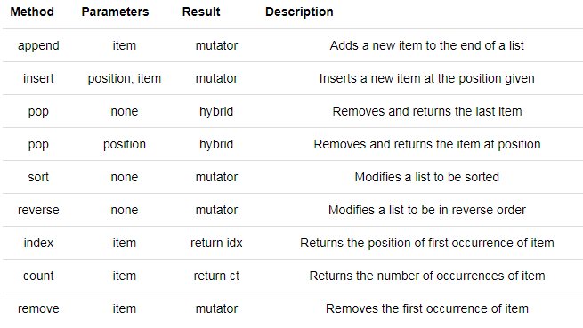

It is important to remember that methods like append, sort, and reverse all return None. They change the list; they don’t produce a new list. So, while we did reassignment to increment a number, as in x = x + 1, doing the analogous thing with these operations will lose the entire list contents (see line 8 below).

```python
mylist = []
mylist.append(5)
mylist.append(27)
mylist.append(3)
mylist.append(12)
print(mylist)

mylist = mylist.sort()   #probably an error
print(mylist)
```

```
[5, 27, 3, 12]
None
```

**Exercise:**

What is printed by the following statements?

```
s = "python rocks"
print(s[3])
```

```
s = "python rocks"
print(s[2] + s[-4])
```

```
alist = [3, 67, "cat", [56, 57, "dog"], [ ], 3.14, False]
print(alist[5])
```

```
s = "python rocks"
print(len(s))
```

```
alist = [3, 67, "cat", 3.14, False]
print(len(alist))
```

```
L = [0.34, '6', 'SI106', 'Python', -2]
print(len(L[1:-1]))
```

```
alist = [1,3,5]
blist = [2,4,6]
print(alist + blist)
```

```
alist = [1,3,5]
print(alist * 3)
```

```
alist = [4,2,8,6,5]
blist = alist
blist[3] = 999
print(alist)
```

```
alist = [4,2,8,6,5]
alist.append(True)
alist.append(False)
print(alist)
```

What is the problem with the given code

```
colors = ["Red", "Orange", "Yellow", "Green", "Blue", "Indigo", "Violet", "Purple", "Pink", "Brown", "Teal", "Turquois", "Peach", "Beige"]

for position in range(len(colors)):
    color = colors[position]
    print(color)
    if color[0] in ["P", "B", "T"]:
        del colors[position]

print(colors)
```

## Tuples

tuple, like a list, is a sequence of items of any type. The printed representation of a tuple is a comma-separated sequence of values, enclosed in parentheses. In other words, the representation is just like lists, except with parentheses () instead of square brackets [].

One way to create a tuple is to write an expression, enclosed in parentheses, that consists of multiple other expressions, separated by commas.

```
julia = ("Julia", "Roberts", 1967, "Duplicity", 2009, "Actress", "Atlanta, Georgia")
```

The key difference between lists and tuples is that a tuple is immutable, meaning that its contents can’t be changed after the tuple is created. We will examine the mutability of lists in detail in the chapter on Mutability.

To create a tuple with a single element (but you’re probably not likely to do that too often), we have to include the final comma, because without the final comma, Python treats the (5) below as an integer in parentheses:

```python
t = (5,)
print(type(t))

x = (5)
print(type(x))
```

```
<class 'tuple'>
<class 'int'>
```

**Tuple Slices**

We can’t modify the elements of a tuple, but we can make a variable reference a new tuple holding different information. Thankfully we can also use the slice operation on tuples as well as strings and lists. To construct the new tuple, we can slice parts of the old tuple and join up the bits to make the new tuple. So julia has a new recent film, and we might want to change her tuple. We can easily slice off the parts we want and concatenate them with the new tuple.

```python
julia = ("Julia", "Roberts", 1967, "Duplicity", 2009, "Actress", "Atlanta, Georgia")
print(julia[2])
print(julia[2:6])

print(len(julia))

julia = julia[:3] + ("Eat Pray Love", 2010) + julia[5:]
print(julia)
```

```
1967
(1967, 'Duplicity', 2009, 'Actress')
7
('Julia', 'Roberts', 1967, 'Eat Pray Love', 2010, 'Actress', 'Atlanta, Georgia')
```

**Tuples are Immutable**

As with strings, if we try to use item assignment to modify one of the elements of a tuple, we get an error. In fact, that’s the key difference between lists and tuples: tuples are like immutable lists. None of the operations on lists that mutate them are available for tuples. Once a tuple is created, it can’t be changed.

```
julia[0] = 'X'  # TypeError: 'tuple' object does not support item assignment
```

# Iteration

A basic building block of all programs is to be able to repeat some code over and over again. Whether it is updating the bank balances of millions of customers each night, or sending email messages to thousands of people programming involves instructing the computer to do many repetitive actions. In computing, we refer to this repetitive execution as iteration. In this section, we will explore some mechanisms for basic iteration.

## The for Loop

In Python, the for statement allows us to write programs that implement iteration. As a simple example, let’s say we have some friends, and we’d like to send them each an email inviting them to our party. We don’t quite know how to send email yet, so for the moment we’ll just print a message for each friend.

```python
for name in ["Joe", "Amy", "Brad", "Angelina", "Zuki", "Thandi", "Paris"]:
    print("Hi", name, "Please come to my party on Saturday!")
```

```
Hi Joe Please come to my party on Saturday!
Hi Amy Please come to my party on Saturday!
Hi Brad Please come to my party on Saturday!
Hi Angelina Please come to my party on Saturday!
Hi Zuki Please come to my party on Saturday!
Hi Thandi Please come to my party on Saturday!
Hi Paris Please come to my party on Saturday!
```

Take a look at the output produced when you press the run button. There is one line printed for each friend. Here’s how it works:

- name in this for statement is called the loop variable or, alternatively, the iterator variable.
- The list of names in the square brackets is the sequence over which we will iterate.
- Line 2 is the loop body. The loop body is always indented. The indentation determines exactly what statements are “in the loop”. The loop body is performed one time for each name in the list.
- On each iteration or pass of the loop, first a check is done to see if there are still more items to be processed. If there are none left (this is called the terminating condition of the loop), the loop has finished. Program execution continues at the next statement after the loop body.
- If there are items still to be processed, the loop variable is updated to refer to the next item in the list. This means, in this case, that the loop body is executed here 7 times, and each time name will refer to a different friend.
- At the end of each execution of the body of the loop, Python returns to the for statement, to see if there are more items to be handled.

- Between the words for and in, there must be a variable name for the loop variable. You can’t put a whole expression there.
- A colon is required at the end of the line
- After the word in and before the colon is an expression that must evaluate to a sequence (e.g, a string or a list or a tuple). It could be a literal, or a variable name, or a more complex expression.

**Strings and for loops**

Since a string is simply a sequence of characters, the for loop iterates over each character automatically. (As always, try to predict what the output will be from this code before your run it.)

```python
for achar in "Go Spot Go":
    print(achar)
```

```
G
o

S
p
o
t

G
o
```

**Lists and for loops**

It is also possible to perform list traversal using iteration by item. A list is a sequence of items, so the for loop iterates over each item in the list automatically.

```python
fruits = ["apple", "orange", "banana", "cherry"]

for afruit in fruits:     # by item
    print(afruit)
```

```
apple
orange
banana
cherry
```

**Using the range Function to Generate a Sequence to Iterate Over**

We are now in a position to understand the inner workings we glossed over previously when we first introduced repeated execution with a for loop. Here was the example:

```python
print("This will execute first")

for _ in range(3):
    print("This line will execute three times")
    print("This line will also execute three times")

print("Now we are outside of the for loop!")
```

```
This will execute first
This line will execute three times
This line will also execute three times
This line will execute three times
This line will also execute three times
This line will execute three times
This line will also execute three times
Now we are outside of the for loop!
```

The range function takes an integer n as input and returns a sequence of numbers, starting at 0 and going up to but not including n. Thus, instead of `range(3)`, we could have written `[0, 1, 2]`.

By contrast, notice that in the previous activecode window, the loop variable is afruit. In that for loop, we do refer to each item, with print(afruit).

**The Accumulator Pattern**

One common programming “pattern” is to traverse a sequence, accumulating a value as we go, such as the sum-so-far or the maximum-so-far. That way, at the end of the traversal we have accumulated a single value, such as the sum total of all the items or the largest item.

- The anatomy of the accumulation pattern includes: initializing an “accumulator” variable to an initial value (such as 0 if accumulating a sum)
- iterating (e.g., traversing the items in a sequence)
- updating the accumulator variable on each iteration (i.e., when processing each item in the sequence)

For example, consider the following code, which computes the sum of the numbers in a list.

```python
nums = [1, 2, 3, 4, 5, 6, 7, 8, 9, 10]
accum = 0
for w in nums:
    accum = accum + w
print(accum)
```

```
55
```

```python
print("range(5): ")
for i in range(5):
    print(i)

print("range(0,5): ")
for i in range(0, 5):
    print(i)

# Notice the casting of `range` to the `list`
print(list(range(5)))
print(list(range(0,5)))

# Note: `range` function is already casted as `list` in the textbook
print(range(5))
```

```
range(5):
0
1
2
3
4
range(0,5):
0
1
2
3
4
[0, 1, 2, 3, 4]
[0, 1, 2, 3, 4]
range(0, 5)
```

We can use the accumulation pattern is count the number of something or to sum up a total. The above examples only covered how to get the sum for a list, but we can also count how many items are in the list if we wanted to.

```python
nums = [1, 2, 3, 4, 5, 6, 7, 8, 9, 10]
count = 0
for w in nums:
    count = count + 1
print(count)
```

```
10
```

**Traversal and the for Loop:**

With a for loop, the loop variable is bound, on each iteration, to the next item in a sequence. Sometimes, it is natural to think about iterating through the positions, or indexes of a sequence, rather than through the items themselves.

```python
fruits = ['apple', 'pear', 'apricot', 'cherry', 'peach']
for n in range(5):
    print(n, fruits[n])
```

```
0 apple
1 pear
2 apricot
3 cherry
4 peach
```

```python
fruits = ['apple', 'pear', 'apricot', 'cherry', 'peach']
for n in range(len(fruits)):
    print(n, fruits[n])
```

```
0 apple
1 pear
2 apricot
3 cherry
4 peach
```

```python
fruits = ['apple', 'pear', 'apricot', 'cherry', 'peach']
for fruit in fruits:
    print(fruit)
```

```
apple
pear
apricot
cherry
peach
```

## While Loop

There is another Python statement that can also be used to build an iteration. It is called the while statement. The while statement provides a much more general mechanism for iterating. Similar to the if statement, it uses a boolean expression to control the flow of execution. The body of while will be repeated as long as the controlling boolean expression evaluates to True.

Here is a new version of the summation program that uses a while statement.

```python
def sumTo(aBound):
    """ Return the sum of 1+2+3 ... n """

    theSum  = 0
    aNumber = 1
    while aNumber <= aBound:
        theSum = theSum + aNumber
        aNumber = aNumber + 1
    return theSum

print(sumTo(4))

print(sumTo(1000))
```

```
10
500500
```

```python
def checkout():
    total = 0
    count = 0
    moreItems = True
    while moreItems:
        price = float(input('Enter price of item (0 when done): '))
        if price != 0:
            count = count + 1
            total = total + price
            print('Subtotal: $', total)
        else:
            moreItems = False
    average = total / count
    print('Total items:', count)
    print('Total $', total)
    print('Average price per item: $', average)

checkout()
```

```
Enter price of item (0 when done): 25
Subtotal: $ 25.0
Enter price of item (0 when done): 12
Subtotal: $ 37.0
Enter price of item (0 when done): 10
Subtotal: $ 47.0
Enter price of item (0 when done): 0
Total items: 3
Total $ 47.0
Average price per item: $ 15.666666666666666
```

**Break and Continue**

Python provides ways for us to control the flow of iteration with a two keywords: break and continue.

break allows the program to immediately ‘break out’ of the loop, regardless of the loop’s conditional structure. This means that the program will then skip the rest of the iteration, without rechecking the condition, and just goes on to the next outdented code that exists after the whole while loop.

continue is the other keyword that can control the flow of iteration. Using continue allows the program to immediately “continue” with the next iteration. The program will skip the rest of the iteration, recheck the condition, and maybe does another iteration depending on the condition set for the while loop.

```python
while True:
    print("this phrase will always print")
    break
    print("Does this phrase print?")

print("We are done with the while loop.")
```

```
this phrase will always print
We are done with the while loop.
```

```python
x = 0
while x < 10:
    print("we are incrementing x")
    if x % 2 == 0:
        x += 3
        continue
    if x % 3 == 0:
        x += 5
    x += 1
print("Done with our loop! X has the value: " + str(x))
```

```
we are incrementing x
we are incrementing x
we are incrementing x
Done with our loop! X has the value: 15
```

**Exercise:**

How many times is the word HELLO printed by the following statements?

```
s = "python rocks"
for ch in s:
   print("HELLO")
```

How many times is the word HELLO printed by the following statements?

```
s = "python rocks"
for ch in s[3:8]:
   print("HELLO")
```

How many times will the for loop iterate in the following statements?

```
p = [3, 4, "Me", 3, [], "Why", 0, "Tell", 9.3]
for ch in p:
   print(ch)
```

How many times is the letter p printed by the following statements?

```
s = "python"
for idx in range(len(s)):
   print(s[idx % 2])
```

The following code contains an infinite loop. Which is the best explanation for why the loop does not terminate?

```
n = 10
answer = 1
while ( n > 0 ):
  answer = answer + n
  n = n + 1
print(answer)
```

Write code to create a list of integers from 0 through 52 and assign that list to the variable numbers. You should use the Python range function and don’t forget to covert the result to a list – do not type out the whole list yourself.

Create a list of numbers 0 through 40 and assign this list to the variable numbers. Then, accumulate the total of the list’s values and assign that sum to the variable sum1.

Write a function, sublist, that takes in a list of numbers as the parameter. In the function, use a while loop to return a sublist of the input list. The sublist should contain the same values of the original list up until it reaches the number 5 (it should not contain the number 5).

# Boolean Values and Boolean Expressions

The Python type for storing true and false values is called bool, named after the British mathematician, George Boole. George Boole created Boolean Algebra, which is the basis of all modern computer arithmetic.

There are only two boolean values. They are True and False. Capitalization is important, since true and false are not boolean values (remember Python is case sensitive).

```python
print(True)
print(type(True))
print(type(False))
```

```
True
<class 'bool'>
<class 'bool'>
```

**Note**

Boolean values are not strings!

It is extremely important to realize that True and False are not strings. They are not surrounded by quotes. They are the only two values in the data type bool. Take a close look at the types shown below.

```python
print(type(True))
print(type("True"))
```

```
<class 'bool'>
<class 'str'>
```

A boolean expression is an expression that evaluates to a boolean value. The equality operator, ==, compares two values and produces a boolean value related to whether the two values are equal to one another.

```python
print(5 == 5)
print(5 == 6)
```

```
True
False
```

In the first statement, the two operands are equal, so the expression evaluates to True. In the second statement, 5 is not equal to 6, so we get False.

The == operator is one of six common comparison operators; the others are:

```
x != y               # x is not equal to y
x > y                # x is greater than y
x < y                # x is less than y
x >= y               # x is greater than or equal to y
x <= y               # x is less than or equal to y
```

Although these operations are probably familiar to you, the Python symbols are different from the mathematical symbols. A common error is to use a single equal sign (=) instead of a double equal sign (==). Remember that = is an assignment operator and == is a comparison operator. Also, there is no such thing as =< or =>.

Note too that an equality test is symmetric, but assignment is not. For example, if a == 7 then 7 == a. But in Python, the statement a = 7 is legal and 7 = a is not. (Can you explain why?)

**Logical operators**

There are three logical operators: and, or, and not. All three operators take boolean operands and produce boolean values. The semantics (meaning) of these operators is similar to their meaning in English:

- x and y is True if both x and y are True. Otherwise, and produces False.
- x or y yields True if either x or y is True. Only if both operands are False does or yield False.
- not x yields False if x is True, and vice versa.

Look at the following example. See if you can predict the output. Then, Run to see if your predictions were correct:

```python
x = True
y = False
print(x or y)
print(x and y)
print(not x)
```

```
True
False
False
```

Although you can use boolean operators with simple boolean literals or variables as in the above example, they are often combined with the comparison operators, as in this example. Again, before you run this, see if you can predict the outcome:

```python
x = 5
print(x > 0 and x < 10)

n = 25
print(n % 2 == 0 or n % 3 == 0)
```

```
True
False
```

The expression `x > 0` and `x < 10` is True only if x is greater than 0 and at the same time, x is less than 10. In other words, this expression is True if x is between 0 and 10, not including the endpoints.

**The in and not in operators**

The in operator tests if one string is a substring of another:

```python
print('p' in 'apple')
print('i' in 'apple')
print('ap' in 'apple')
print('pa' in 'apple')
```

```
True
False
True
False
```

Note that a string is a substring of itself, and the empty string is a substring of any other string. (Also note that computer scientists like to think about these edge cases quite carefully!)

```python
print('a' in 'a')
print('apple' in 'apple')
print('' in 'a')
print('' in 'apple')
```

```
True
True
True
True
```

The not in operator returns the logical opposite result of in.

```python
print('x' not in 'apple')
```

```
True
```

We can also use the in and not in operators on lists!

```python
print("a" in ["a", "b", "c", "d"])
print(9 in [3, 2, 9, 10, 9.0])
print('wow' not in ['gee wiz', 'gosh golly', 'wow', 'amazing'])
```

```
True
True
False
```

```python
print("a" in ["apple", "absolutely", "application", "nope"])
```

```
False
```

# Conditional Execution

In order to write useful programs, we almost always need the ability to check conditions and change the behavior of the program accordingly. Selection statements, sometimes also referred to as conditional statements, give us this ability. The simplest form of selection is the if statement. This is sometimes referred to as binary selection since there are two possible paths of execution.

```python
x = 15

if x % 2 == 0:
    print(x, "is even")
else:
    print(x, "is odd")
```

```
15 is odd
```

**Chained conditionals**

```
if x < y:
    print("x is less than y")
elif x > y:
    print("x is greater than y")
else:
    print("x and y must be equal")
```

```python
x = 10
y = 10

if x < y:
    print("x is less than y")
elif x > y:
    print("x is greater than y")
else:
    print("x and y must be equal")
```

```
x and y must be equal
```

**Exercise:**

How many lines of code can appear in the indented code block below the if and else lines in a conditional?

What does the following code print? (choose from output a, b, c or nothing)

```
if (4 + 5 == 10):
    print("TRUE")
else:
    print("FALSE")
```

What does the following code print?

```
if (4 + 5 == 10):
    print("TRUE")
else:
    print("FALSE")
print("TRUE")
```

Will the following code cause an error?

```
x = -10
if x < 0:
    print("The negative number ",  x, " is not valid here.")
else:
    print(x, " is a positive number")
else:
    print("This is always printed")
```

What will the following code print if x = 3, y = 5, and z = 2?

```
if x < y and x < z:
    print("a")
elif y < x and y < z:
    print("b")
else:
    print("c")
```

Write code to assign the string "You can apply to SI!" to output if the string "SI 106" is in the list courses.

If it is not in courses, assign the value "Take SI 106!" to the variable output.

```
courses = ["ENGR 101", "SI 110", "ENG 125", "SI 106", "CHEM 130"]
```

For each string in the list words, find the number of characters in the string. If the number of characters in the string is greater than 3, add 1 to the variable num_words so that num_words should end up with the total number of words with more than 3 characters.

```
words = ["water", "chair", "pen", "basket", "hi", "car"]
```

## Nested conditionals

one conditional can also be nested within another. For example, assume we have two integer variables, x and y. The following pattern of selection shows how we might decide how they are related to each other.

```
if x < y:
    print("x is less than y")
else:
    if x > y:
        print("x is greater than y")
    else:
        print("x and y must be equal")
```

Here is a complete program that defines values for x and y. Run the program and see the result. Then change the values of the variables to change the flow of control.

```python
x = 10
y = 10

if x < y:
    print("x is less than y")
else:
    if x > y:
        print("x is greater than y")
    else:
        print("x and y must be equal")
```

```
x and y must be equal
```

**Exercise:**

Will the following code cause an error?

```
x = -10
if x < 0:
    print("The negative number ",  x, " is not valid here.")
else:
    if x > 0:
        print(x, " is a positive number")
    else:
        print(x," is 0")
```

A year is a leap year if it is divisible by 4; however, if the year can be evenly divided by 100, it is NOT a leap year, unless the year is also evenly divisible by 400 then it is a leap year. Write code that asks the user to input a year and output True if it’s a leap year, or False otherwise. Use if statements.

Year Leap?

1944 True

2011 False

1986 False

1800 False

2000 True

2056 True